# Introduction to R

> In the 1990’s, Gentleman and Ihaka created the work-alike ‘R’ system, as an open source project which spread rapidly. R is today the dominant quantitative programming environment used in academic Statistics, with a very impressive on-line following.Donoho ([2015](http://ixdatascience.bitbucket.org/02-N-r-introduction.html#ref-donoho-50-years-data-science))

# 1 R from the Command Line

It’s easy to get R up and running in a console window.

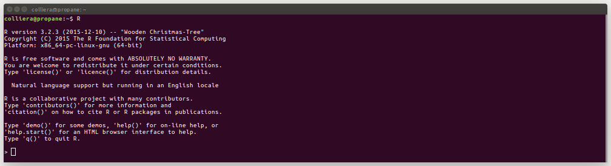

Running R in a console.

This is very convenient if you are doing something quick and dirty. But if you’re engaging in anything non-trivial then it makes sense to fire up RStudio.

# 2 RStudio

Grab the most recent [preview version](http://www.rstudio.com/products/rstudio/download/preview/) of RStudio.

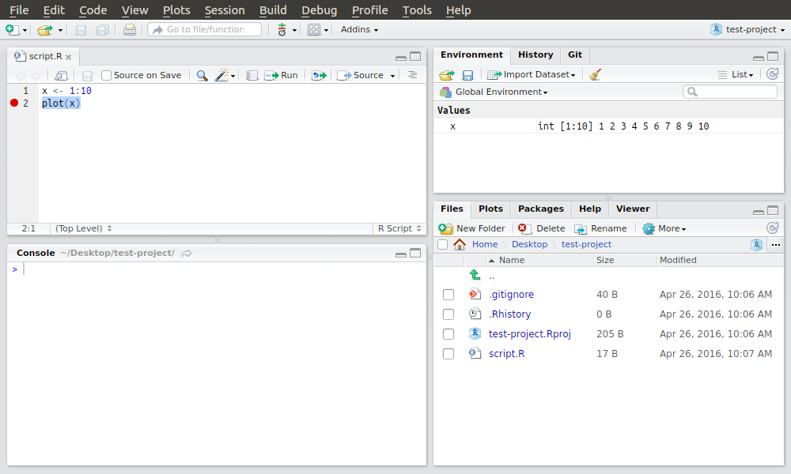

The RStudio desktop.

The RStudio IDE has a number of panels, the most important of which (IMHO) are the Source and Console panels, which by default are on the left. You’ll build scripts in the former and execute commands in the latter. The whole layout of the IDE is fully configurable, so you can set it up in whatever way works best for you. I’d suggest that you always have the following tabs visible because you’ll use them all the time:

- Environment,
- History,
- Git [only visible if your project has version control enable],
- Files,
- Plots and
- Help.

The Packages tab is useful, but I generally install and load packages using the Console.

There’s an enormous amount of functionality available in RStudio. Check out the [RStudio Cheat Sheet](http://www.rstudio.com/wp-content/uploads/2016/01/rstudio-IDE-cheatsheet.pdf) to learn more.

## 2.1 Projects

Files can be bound together into Projects. For organisational purposes this is extremely helpful. I’d suggest that whenever you start working on something new you should initiate a new project. One of the great features of projects is that you can close on project, go and work on another project and then, when you return to the original project, find it in the precise state in which you left it. Same files open, same data loaded. Everything just as it was.

# 3 R as a Scientific Calculator

At its lowest level R is an extremely sophisticated Scientific Calculator. You can use it to perform arbitrary arithmetic calculations.

```r
(1 + 7) / 4
```

```
[1] 2
```

There is an extensive array of built-in mathematical functions as well.

```r
sqrt(2); cos(pi)
```

```
[1] 1.4142
```

```
[1] -1
```

# 4 Extending R

R comes with a small mountain of integrated functionality. A set of recommended packages are distributed with R. However, these are dwarfed in number by the contributed packages available through the [Comprehensive R Archive Network (CRAN)](http://cran.r-project.org/) and elsewhere. Packages on CRAN have been through an intensive validation process, so they can be regarded as stable and reliable.

## 4.1 Installing from CRAN

Installing a package from CRAN is simple using `install.packages()`.

```r
install.packages("devtools")
```

Once the package has been installed it can be loaded into the R interpreter using `library()` or `require()`.

```r
library(devtools)
```

Help on a particular package can be accessed by using the `package` argument to `help()`.

```r
help(package = "devtools")
```

Another view on package documentation can be accessed with `library()`.

```r
library(help = "devtools")
```

An interesting and useful feature of CRAN is [Task Views](https://cran.r-project.org/web/views/), which break the myriad packages down according to their main application domain. The [Time Series Analysis](https://cran.r-project.org/web/views/TimeSeries.html) task view, for example, lists and gives a brief description of all of the packages on CRAN which are relevant to time series analysis.

## 4.2 Installing from GitHub

Some packages are hosted on GitHub. These are generally packages which are new or in active development. These are installed using `install_github()` from the `devtools` package.

```r
install_github("klutometis/roxygen")
```

# 5 Getting Help

You can get help on a R function by selecting the Help tab in RStudio and then entering the function name into the search box. Or, alternatively, you can access the help via the console using the `?` operator. For example, `?sin` will bring up documentation on Trigonometric Functions. There are a few edge cases where this doesn’t work too well. In these cases you can use the `help()` function, for example, `help("[[")`. Or you can use quotes, for example, `?"if"`. If you’re not quite sure of the name of a function, you can use the `??` operator to search all of the documentation. For example, `??eigenvalue` will bring up links to all documents which mention the term “eigenvalue”.

```
 setting  value
 version  R version 3.3.0 (2016-05-03)
 system   x86_64, linux-gnu
 ui       X11
 language en_ZA:en
 collate  en_ZA.UTF-8
 tz       <NA>
 date     2016-05-29

 package    * version    date       source
 colorspace   1.2-6      2015-03-11 CRAN (R 3.3.0)
 devtools     1.11.1     2016-04-21 CRAN (R 3.3.0)
 digest       0.6.9      2016-01-08 CRAN (R 3.3.0)
 evaluate     0.9        2016-04-29 CRAN (R 3.3.0)
 formatR      1.4        2016-05-09 CRAN (R 3.3.0)
 ggplot2    * 2.1.0      2016-03-01 CRAN (R 3.3.0)
 gtable       0.2.0      2016-02-26 CRAN (R 3.3.0)
 htmltools    0.3.5      2016-03-21 CRAN (R 3.3.0)
 knitr        1.13       2016-05-09 CRAN (R 3.3.0)
 magrittr     1.5        2014-11-22 CRAN (R 3.3.0)
 memoise      1.0.0      2016-01-29 CRAN (R 3.3.0)
 munsell      0.4.3      2016-02-13 CRAN (R 3.3.0)
 plyr         1.8.3      2015-06-12 CRAN (R 3.3.0)
 Rcpp         0.12.5     2016-05-14 CRAN (R 3.3.0)
 rmarkdown    0.9.6      2016-05-01 CRAN (R 3.3.0)
 scales       0.4.0      2016-02-26 CRAN (R 3.3.0)
 stringi      1.1.1      2016-05-15 Github (Rexamine/stringi@ab080d9)
 stringr      1.0.0.9000 2016-05-15 Github (hadley/stringr@a67f8f0)
 withr        1.0.1      2016-02-04 CRAN (R 3.3.0)
 yaml         2.1.13     2014-06-12 CRAN (R 3.3.0)
```

# 6 Variables

As one would expect, R has the ability to store values in variables. Assignment is made using either the `=` or `<-` operator, although the latter is more idiomatic of R.

```r
x = 3
y <- 9
```

Note that the value assigned is not echoed. To make this happen you simply enclose the assignment in parentheses.

```r
(z = 5)
```

```
[1] 5
```

Variables can be destroyed using `rm()`.

```r
rm(y)
```

A list of defined variables is returned by `ls()`.

```r
ls()
```

```
[1] "cran"           "key.sequence"   "menu.sequence"  "twitter.handle" "twitter.hash"
[6] "x"              "z"
```

# 7 Data Types

R supports a variety of data types. In addition to the built-in types listed below (which are generally more than enough for most applications), it also has the capacity for user defined types.

R is dynamically typed, which means that the type of a variable need not be declared in advance and, furthermore, may be readily changed. The data type of a literal or variable can be queried using `class()`.

## 7.1 Numeric

For numerical computations R caters for integer, real or “numeric” (double precision floating point) and complex numbers. We’ll ignore complex numbers since they have little relevance to Data Science. By default numbers are treated as real. A number must be explicitly declared as an integer using an `L` suffix.

```r
class(3)
```

```
[1] "numeric"
```

```r
class(3L)
```

```
[1] "integer"
```

There are functions for creating and testing for integers.

```r
as.integer(3.5)
```

```
[1] 3
```

```r
is.integer(3L)
```

```
[1] TRUE
```

There are analogous functions, `as.numeric()` and `is.numeric()`.

It’s worthwhile to note that comparisons on `numeric` objects can be tricky.

```r
(x <- sqrt(2)**2)
```

```
[1] 2
```

It looks like 2. It smells like 2. But apparently it’s not *exactly* 2…

```r
x == 2
```

```
[1] FALSE
```

… because limited numerical precision causes it to differ every so slightly.

```r
x - 2
```

```
[1] 4.4409e-16
```

To get around these slight numerical imperfections, rather use `all.equal()` to make comparisons.

```r
all.equal(x, 2)
```

```
[1] TRUE
```

There are a couple of special values for the `numeric` type:

```r
c(-1, 0, 1) / 0
```

```
[1] -Inf  NaN  Inf
```

The functions `is.finite()`, `is.infinite()` and `is.nan()` can be used to test for these.

### 7.1.1 Numeric Operators

All of the usual numeric operators are defined: `+`, `-`, `/`, `*`, `^` or `**`, `%/%` (integer division) and `%%` (remainder after integer division).

## 7.2 Logical

Data of logical type can only take on one of two possible values: `TRUE` or `FALSE` (although these can be abbreviated as `T` and `F`).

You can use the `&&` (and), `||` (or) and `!` (not) operators to combine logical expressions.

## 7.3 Character

Strings are enclosed between either single or double quotation marks.

```r
"This is a string"
```

```
[1] "This is a string"
```

```r
name <- "John Smith"
class(name)
```

```
[1] "character"
```

There are a number of built-in functions for working with strings.

```r
nchar(name)
```

```
[1] 10
```

```r
substr(name, 1, 4)
```

```
[1] "John"
```

```r
paste("foo", "bar")
```

```
[1] "foo bar"
```

```r
strsplit("foo bar", split = " ")
```

```
[[1]]
[1] "foo" "bar"
```

If you’ve done any programming in a C-like language before then you’ll be familiar with `sprintf()`.

```r
sprintf("I'm %s and I'm %d years old.", name, 23)
```

```
[1] "I'm John Smith and I'm 23 years old."
```

The `stringi` and `stringr` packages provide alternative sets of functions for string manipulation. We’ll look closer at these later.

## 7.4 Dates and Times

There are a few types for handling date and time data: `POSIXlt`, `POSIXct` and `Date`. Let’s start by looking at `Date`.

```r
Sys.Date()
```

```
[1] "2016-05-29"
```

```r
Sys.Date() - as.Date("1972-06-16")
```

```
Time difference of 16053 days
```

The main difference between `POSIXlt` and `POSIXct` is their underlying representation. Whereas `POSIXlt` (`lt` = long type) has a more informative representation, `POSIXct` (`ct` = compact type) is more compact. I tend to favour the latter.

```r
Sys.time()
```

```
[1] "2016-05-29 18:37:50 SAST"
```

```r
now <- as.POSIXlt(Sys.time(), "UTC")
strftime(now, "%H:%M %d/%m/%y")
```

```
[1] "16:37 29/05/16"
```

The `lubridate` package implements a powerful set of functions for dealing with dates and times.

## 7.5 Vectors

Vectors are formed using the `c()` function.

```r
x <- c(1, 1, 2, 3, 5, 8, 13, 21)
```

Elements of a vector are referred to using the `[]` subscript operator. The first element in a vector has index 1.

```r
x[4]
```

```
[1] 3
```

```r
x[9] = 34
(x = c(x, 55))
```

```
 [1]  1  1  2  3  5  8 13 21 34 55
```

```r
length(x)
```

```
[1] 10
```

One vector can be used to index into another vector.

```r
x[c(1, 3, 5, 7)]
```

```
[1]  1  2  5 13
```

A vector can only contain elements of a single type. If they have mixed type then they are coerced to the most general type.

```r
(y <- c("John", 63, FALSE))
```

```
[1] "John"  "63"    "FALSE"
```

Elements of a vector can be named.

```r
c(one  = 1, two = 2, three = 3)
```

```
  one   two three
    1     2     3
```

### 7.5.1 Missing Data

Missing elements in a vector are denoted by `NA`.

```r
x[3] = NA
x
```

```
 [1]  1  1 NA  3  5  8 13 21 34 55
```

The `is.na()` function tests for missing values.

There is also a reserved word `NULL` which has a slightly different interpretation. `NULL` is often used to indicate that a result is undefined or that there is no result. Effectively `NULL` is a vector of length zero. There are `as.null()` and `is.null()` functions for dealing with NULL values.

### 7.5.2 Generating Regular Sequences

The `:` operator is used to generate regular sequences.

```r
4:6
```

```
[1] 4 5 6
```

These sequences can be used to index vectors.

```r
x[4:6]
```

```
[1] 3 5 8
```

A more flexible method to generate a sequence is provided by the `seq()` family of functions. Have a look at the documentation for further details.

```r
seq(-4,  4, by = 2)
```

```
[1] -4 -2  0  2  4
```

```r
seq(as.Date("2016/06/01"), as.Date("2016/07/01"), by = "week")
```

```
[1] "2016-06-01" "2016-06-08" "2016-06-15" "2016-06-22" "2016-06-29"
```

### 7.5.3 Repetition

One commonly needs to build a vector by repeating a particular value a number of times.

```r
rep(0, 5)
```

```
[1] 0 0 0 0 0
```

If the first argument is a vector then there are two possible behaviours.

```r
rep(1:3, 5)
```

```
 [1] 1 2 3 1 2 3 1 2 3 1 2 3 1 2 3
```

```r
rep(1:3, each = 5)
```

```
 [1] 1 1 1 1 1 2 2 2 2 2 3 3 3 3 3
```

### 7.5.4 Unique Values and Sorting

Use `unique()` to extract the distinct values from a vector.

```r
unique(c(3, 2, 2, 2, 2, 3, 1, 1, 2, 3))
```

```
[1] 3 2 1
```

Use `sort()` to impose order on seemingly random data.

```r
heights
```

```
 [1] 178.5 170.8 190.6 192.0 164.7 168.7 167.1 186.4 174.4 175.2
```

```r
sort(heights)
```

```
 [1] 164.7 167.1 168.7 170.8 174.4 175.2 178.5 186.4 190.6 192.0
```

Whereas `order()` will give the indices for sorting the data. Carefully look at the results below and make sure that you understand what they mean. Try using these indices to sort the data.

```r
order(heights)
```

```
 [1]  5  7  6  2  9 10  1  8  3  4
```

Both `sort()` and `order()` have a `decreasing` parameter which allows you to reverse the sense of the sort.

### 7.5.5 Vectors of Logical

Many operations in R are vectorised. When comparison operators are applied to a vector, the result is a vector of logical type.

```r
x > 5
```

```
 [1] FALSE FALSE    NA FALSE FALSE  TRUE  TRUE  TRUE  TRUE  TRUE
```

The functions `all()` and `any()` can be used to check whether all or at least one of the elements in a logical vector is `TRUE`.

```r
all(x > 5)
```

```
[1] FALSE
```

```r
any(x > 5)
```

```
[1] TRUE
```

The `which()` function returns the indices of the `TRUE` elements in a vector.

```r
which(c(T, F, T, F, T))
```

```
[1] 1 3 5
```

Logical vectors can also be used as indexes into other vectors.

```r
x[c(T, T, F, F, T, T, F, F, T, T)]
```

```
[1]  1  1  5  8 34 55
```

Logical vectors can be combined using the vectorised forms of the logical operators, `&` and `|`.

## 7.6 Matrices

R also has support for `matrix` (two dimensions) and `array` (multiple dimensions). In many scenarios the two data types can be used interchangeably.

```r
A = matrix(1:9, nrow = 3)
B = matrix(0, nrow = 3, ncol = 3)
```

Matrix data can be concatenated by row or by column using `cbind()` and `rbind()`.

```r
cbind(A, B)
```

```
     [,1] [,2] [,3] [,4] [,5] [,6]
[1,]    1    4    7    0    0    0
[2,]    2    5    8    0    0    0
[3,]    3    6    9    0    0    0
```

```r
rbind(A, B)
```

```
     [,1] [,2] [,3]
[1,]    1    4    7
[2,]    2    5    8
[3,]    3    6    9
[4,]    0    0    0
[5,]    0    0    0
[6,]    0    0    0
```

The slicing operator can be used to extract portions of a matrix.

```r
A[2,2]      # Extract a single element
```

```
[1] 5
```

```r
A[,2]       # Extract the second column
```

```
[1] 4 5 6
```

```r
A[1,]       # Extract the first row
```

```
[1] 1 4 7
```

```r
A[1:2,]     # Extract the first two rows
```

```
     [,1] [,2] [,3]
[1,]    1    4    7
[2,]    2    5    8
```

```r
A[,-3]      # Extract everything except the third column
```

```
     [,1] [,2]
[1,]    1    4
[2,]    2    5
[3,]    3    6
```

## 7.7 Factors

Factors are used represent categorical data. This idea is best illustrated with an example.

```r
(genders = factor(c("M", "F", "F", "M", "M")))
```

```
[1] M F F M M
Levels: F M
```

The categories captured by a factor variable can be accessed via `levels()`.

```r
levels(genders)
```

```
[1] "F" "M"
```

Factors are really a specialised form of integer vector. Each level of a factor corresponds to an integer value. A factor is rather efficient because it stores these integer values rather than the string labels.

```r
as.integer(genders)
```

```
[1] 2 1 1 2 2
```

A factor can also be used to represent categorical data where there is an ordinal relationship between the categories.

```r
factor(c("S", "L", "XL", "M", "XL", "S"), levels = c("S", "M", "L", "XL"), ordered = TRUE)
```

```
[1] S  L  XL M  XL S
Levels: S < M < L < XL
```

Numerical variables can be transformed into factors using `cut()`.

```r
cut(heights, breaks = c(60, 165, 180, 240), labels = c("short", "regular", "tall"))
```

```
 [1] regular regular tall    tall    short   regular regular tall    regular regular
Levels: short regular tall
```

## 7.8 Lists

Lists are a generalisation of the vector in which the elements need not be of the same type. The elements of a vector can take on *any* type.

```r
(stuff <- list(numbers = 1:5, names = c("Bob", "Mary", "Alice"), pi = 22 / 7))
```

```
$numbers
[1] 1 2 3 4 5

$names
[1] "Bob"   "Mary"  "Alice"

$pi
[1] 3.1429
```

There are a variety of ways to index the elements of a list.

```r
stuff$names
```

```
[1] "Bob"   "Mary"  "Alice"
```

```r
stuff["numbers"]
```

```
$numbers
[1] 1 2 3 4 5
```

```r
(pi_list = stuff[3]); class(pi_list)
```

```
$pi
[1] 3.1429
```

```
[1] "list"
```

```r
(pi_numeric = stuff[[3]]); class(pi_numeric)
```

```
[1] 3.1429
```

```
[1] "numeric"
```

Note the subtle difference between the results of the `[[]]` and `[]` operators: the former returns a item from the list and the latter returns a portion of the list (but as a list!).

A list is a convenient structure to use for returning multiple values from a function.

```r
rversion = R.Version()
class(rversion)
```

```
[1] "list"
```

We can find the labels for the various elements in the list using the `names()` function.

```r
names(rversion)
```

```
 [1] "platform"       "arch"           "os"             "system"         "status"
 [6] "major"          "minor"          "year"           "month"          "day"
[11] "svn rev"        "language"       "version.string" "nickname"
```

```r
rversion$nickname
```

```
[1] "Supposedly Educational"
```

## 7.9 Data Frames

You are going to be using data frames a lot, so pay attention now! Data frames are particularly useful because they represent data in tabular form. Many sets of data come along with R and the majority of them are stored as data frames. Let’s have a look at an example.

```r
class(airquality)
```

```
[1] "data.frame"
```

```r
head(airquality)
```

```
  Ozone Solar.R Wind Temp Month Day
1    41     190  7.4   67     5   1
2    36     118  8.0   72     5   2
3    12     149 12.6   74     5   3
4    18     313 11.5   62     5   4
5    NA      NA 14.3   56     5   5
6    28      NA 14.9   66     5   6
```

The `head()` function shows us the first few records in the data frame. There’s also a `tail()` function which shows the bottom of the data frame.

We can build our own data frame using the `data.frame()` function.

```r
folk <- data.frame(index = 1:3,
                   names = c("Bob", "Mary", "Alice"),
                   ages = c(43, 25, 31),
                   heights = c(1.82, 1.75, 1.77))
folk
```

```
  index names ages heights
1     1   Bob   43    1.82
2     2  Mary   25    1.75
3     3 Alice   31    1.77
```

We can query the dimensions of the data frame and also find the names of the columns.

```r
dim(folk)
```

```
[1] 3 4
```

```r
nrow(folk)
```

```
[1] 3
```

```r
ncol(folk)
```

```
[1] 4
```

```r
names(folk)
```

```
[1] "index"   "names"   "ages"    "heights"
```

Columns are accessed using the `$` operator which we saw earlier applied to lists (a data frame is actually just a glorified list).

```r
folk$names
```

```
[1] Bob   Mary  Alice
Levels: Alice Bob Mary
```

The `[]` operator can also be applied to a data frame to access columns, rows and individual cells.

```r
folk[, 2]
```

```
[1] Bob   Mary  Alice
Levels: Alice Bob Mary
```

```r
folk[1:2,]
```

```
  index names ages heights
1     1   Bob   43    1.82
2     2  Mary   25    1.75
```

```r
folk[2, 2]
```

```
[1] Mary
Levels: Alice Bob Mary
```

It can get a little tedious to keep on referring to columns in a data frame using the `$` notation. A way around this is to `attach()` a data frame.

```r
attach(folk)
names
```

```
[1] Bob   Mary  Alice
Levels: Alice Bob Mary
```

```r
ages
```

```
[1] 43 25 31
```

```r
detach(folk)
```

When you are done it’s *very* important to `detach()` the data frame, otherwise things can get rather cluttered. The same thing can be done with lists.

The concatenation functions `cbind()` and `rbind()` also work with data frames. You also have the possibility of joining two data frames using common columns with `merge()`.

# 8 Exercises

1. [5 minutes] If `x = 1:100` how would you use indexing notation to extract the elements of `x` which are divisible by 3?
2. [10 minutes] Enter the following data into a vector: 244, 191, 160, 187, 180, NA, 174, 205, 211, 183, NA, 180, 194, 200.
- Replace the NA values with 0.
- Print the vector containing the odd numbered observations in two ways:
  - by selecting the odd numbered observations; and
  - by omitting the even numbered observations.
- Print out the observations which are less than 190.
3. [20 minutes] Create a data frame with the following data:

```
   Age Mass Gender Appointment
1   16   63      M    1/1/2016
2   18   68      F    2/1/2016
3   20   73      M    3/1/2016
4   22   76      F    4/1/2016
5   24   82      M    5/1/2016
6   26   83      F    6/1/2016
7   28   91      M    7/1/2016
8   30   86      F    8/1/2016
9   32   82      M    9/1/2016
10  34   78      F   10/1/2016
11  36   73      M   11/1/2016
12  38   68      F   12/1/2016
13  40   63      M    1/1/2017
```

- How many rows and columns does the data frame have?
- What class of data is in each column?
- The receptionist accidentally entered the appointment data incorrectly. All of the appointments should occur on the 15th of each month, not the 1st. Update the data to reflect this change.
- How many patients are above the age of 20?
- How many patients have a mass less than 80?
- [Bonus Question] How many patients are female, above the age of 20 and have a mass less than 80?
4. [10 minutes] Look at the Violent Crime Rates by US State data.

```r
data(USArrests)
```

- Which state has the lowest murder rate?
- Which states have murder rates less than 4.0?
- Which states are in the top quartile for urban population?
- [Bonus Question] Subset the data so that you only include the states that are in the top quartile for their urban population. In this new dataset, what is the average murder rate for those states?

# Resources

Donoho, David. 2015. “50 years of Data Science.” In *Tukey Centennial Workshop*. Princeton, NJ.